# R Notebook

```r
library(tidyverse)
library(ggplot2)
library(lme4)
```

Read data of different years

```r
finaldf <- read.csv("combineddf.csv")
finaldf %>% head()
```

|  | PID | LIVING_AREA | GROSS_AREA | LU | ZIPCODE | TOTAL_VALUE | YEAR |
| --- | --- | --- | --- | --- | --- | --- | --- |
| 1 | 2205668000 | 2834 | 4291 | R3 | 02135 | 604700 | 2014 |
| 2 | 2205667000 | 0 | 0 | RL | 02135 | 40600 | 2014 |
| 3 | 2205665004 | 1401 | 1401 | CD | 02135 | 335400 | 2014 |
| 4 | 2205665002 | 1410 | 2777 | CD | 02135 | 357300 | 2014 |
| 5 | 2205664000 | 2952 | 4346 | R2 | 02135 | 567000 | 2014 |
| 6 | 2205663001 | 2390 | 4240 | R1 | 02135 | 477600 | 2014 |

Print number of parcels

```r
finaldf %>% dim()
```

```
[1] 1371391       7
```

```r
finaldf %>% dplyr::filter(is.na(LIVING_AREA)) %>% nrow()
```

```
[1] 0
```

We remove rows with NAs in LIVING_AREA.

```r
finaldf <- finaldf %>% dplyr::filter(!is.na(LIVING_AREA))
```

Distribution of living area grouped by land usage. For the “A” and “RL” categories, there are properties with living area $1$, which must be systematically wrong.

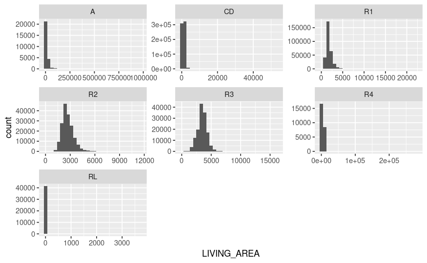

```r
p <- finaldf %>% ggplot(aes(x=LIVING_AREA)) + geom_histogram() +
  facet_wrap(vars(LU), scales="free")
p
```

Find extremes of living areas. Even filtering out parcels with positive living area, there are still parcels with living area $1$.

```r
finaldf %>% dplyr::filter(LIVING_AREA > 0) %>%
  group_by(LU) %>%
  summarize(maxval = max(LIVING_AREA), minval = min(LIVING_AREA))
```

| LU | maxval | minval |
| --- | --- | --- |
| A | 968545 | 1 |
| CD | 52936 | 1 |
| R1 | 22159 | 168 |
| R2 | 11544 | 36 |
| R3 | 16068 | 90 |
| R4 | 279125 | 1 |
| RL | 3708 | 1 |

```r
finaldf %>%
  dplyr::filter(LIVING_AREA > 1) %>%
  dplyr::filter(LU == "R4") %>% arrange(LIVING_AREA)
```

| PID | LIVING_AREA | GROSS_AREA | LU | ZIPCODE | TOTAL_VALUE | YEAR |
| --- | --- | --- | --- | --- | --- | --- |
| 801580001 | 360 | 720 | R4 | 02118 | 642699 | 2015 |
| 801580001 | 360 | 720 | R4 | 02118 | 597910 | 2016 |
| 801580001 | 360 | 720 | R4 | 02118 | 651083 | 2017 |
| 801580001 | 360 | 720 | R4 | 02118 | 678298 | 2018 |
| 801580001 | 360 | 720 | R4 | 02118 | 714435 | 2019 |
| 1302500000 | 536 | 536 | R4 | 02125 | 419000 | 2015 |
| 1302500000 | 536 | 536 | R4 | 02125 | 480000 | 2016 |
| 1302500000 | 536 | 536 | R4 | 02125 | 531500 | 2017 |
| 1302500000 | 536 | 536 | R4 | 02125 | 563000 | 2018 |
| 1302500000 | 536 | 536 | R4 | 02125 | 591000 | 2019 |

[output cut: 990 more lines]

```r
finaldf %>%
  dplyr::filter(LIVING_AREA > 1) %>%
  arrange(LIVING_AREA)
```

[output not shown]

Filter out parcels with less than $300$ square feet living area. For all the residential codes, $300$ square feet is a reasonable amount of living space. We do this to remove parcels that have unreliable records of living area. This retains most of the parcels (1302048 out of 1371391).

```r
threshold <- 300
finaldf <- finaldf %>% dplyr::filter(LIVING_AREA > threshold)

finaldf %>% nrow()
```

[output not shown]

Distribution of living area. Discard the RL (residential lot) category. As we move from CD -> R1 -> R2 -> R3 -> R4 -> A, the mass of the log living area variable shifts to the right, which is in agreement with the expectation that residential parcels for more families should have more living area.

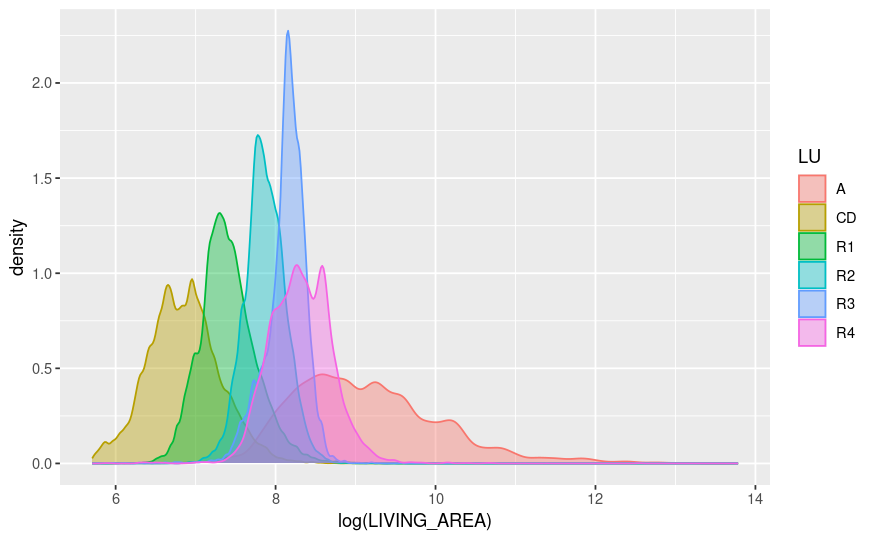

```r
p <- finaldf %>%
  dplyr::filter(LU != "RL") %>%
  ggplot(aes(x=log(LIVING_AREA), color=LU)) + geom_density(aes(fill=LU), alpha = 0.4)
p
```